# Temporal Hawkes process: simulation by thinning, fitting by maximum likelihood

This notebook builds a Hawkes process from scratch, independently of Robert’s branching simulator, and fits it. The code lives in `src/stpp/hawkes_temporal.py`.

|  | Notebook 01 (Robert’s approach) | This notebook |
| --- | --- | --- |
| Dimensions | space and time | time only |
| Simulation | branching: build family trees | **Ogata thinning**: follow the intensity forward in time |
| Likelihood cost | $O(n^2)$, all pairs | **$O(n)$**, by a recursion |
| Gradient | finite differences | **exact**, by a second recursion |
| Model check | parameter recovery | parameter recovery, **time-rescaling residuals**, and a **test against Poisson** |

# 1. The model

Event times $0 < t_1 < t_2 < \dots < t_n \le T$. The conditional intensity is

$$\lambda(t) = \mu + \sum_{t_j < t} \alpha\,\beta\, e^{-\beta (t - t_j)}.$$

- $\mu$: the background rate.
- $\alpha$: the **branching ratio**. The kernel $\beta e^{-\beta u}$ integrates to 1, so each event triggers on average $\alpha$ direct children.
- $\beta$: the decay rate. The average delay from parent to child is $1/\beta$.

Each event makes $\lambda$ **jump up by $\alpha\beta$**, and between events $\lambda$ **decays exponentially back towards $\mu$**. Events make more events, which produces clusters. The process is stationary only if $\alpha < 1$. Its long-run event rate is $E[\lambda] = \mu / (1 - \alpha)$: $\mu$ immigrants per unit time, each bringing on average $1/(1-\alpha)$ events including itself.

# 2. Simulation by thinning

## The idea

To simulate a Poisson process with *constant* rate $\bar\lambda$, draw $\text{Exp}(\bar\lambda)$ waiting times. **Thinning** (Lewis–Shedler; Ogata, 1981) handles a *varying* rate $\lambda(t) \le \bar\lambda$:

1. Propose candidate points from a Poisson process with the larger rate $\bar\lambda$.
2. Keep a candidate at time $t$ with probability $\lambda(t)/\bar\lambda$.

**Why it works.** In a tiny interval $dt$, a candidate appears with probability $\bar\lambda\,dt$ and is kept with probability $\lambda(t)/\bar\lambda$. So an event occurs with probability $\bar\lambda\,dt \cdot \lambda(t)/\bar\lambda = \lambda(t)\,dt$, which is exactly the target intensity.

**Finding a bound for a Hawkes process.** Between events, $\lambda(t)$ only *decreases*. So the intensity right now is an upper bound until the next event. Each time we accept a point, $\lambda$ jumps up and we take a new bound. Rejected candidates still help: they move the clock forward, and the bound is reset at each one.

## The code, line by line

```python
def simulate_hawkes_thinning(mu, alpha, beta, T, seed=None):
    if not 0 <= alpha < 1:
        raise ValueError("alpha must be in [0, 1) ...")
    rng = np.random.default_rng(seed)
    events = []
    t = 0.0
    excitation = 0.0

    while True:
        lam_bar = mu + excitation
        w = rng.exponential(1 / lam_bar)
        t += w
        if t > T:
            break
        excitation *= np.exp(-beta * w)
        lam_t = mu + excitation
        if rng.uniform() * lam_bar <= lam_t:
            events.append(t)
            excitation += alpha * beta
    return np.array(events)
```

**1**

Refuse $\alpha \ge 1$. The process would explode and the loop might never reach $T$.

**2**

A seeded random-number generator, so a simulation can be reproduced.

**3**

The accepted event times.

**4**

The clock. It moves forward through candidate times.

**5**

The **state variable**: $E(t) = \sum_{t_j<t}\alpha\beta e^{-\beta(t-t_j)}$, so that $\lambda(t) = \mu + E(t)$. Because the kernel is exponential, we never need to revisit past events. $E$ just decays by a factor $e^{-\beta w}$ over a gap $w$ and jumps by $\alpha\beta$ at each event. This is the *Markov property* of the exponential Hawkes process, and it makes the simulator $O(n)$.

**6**

The **bound** $\bar\lambda$. It equals the current intensity, which can only fall until the next accepted event.

**7**

A **candidate waiting time** from a Poisson clock with rate $\bar\lambda$: $w \sim \text{Exp}(\bar\lambda)$. NumPy takes the mean $1/\bar\lambda$.

**8**

Move the clock to the candidate time.

**9**

Past the end of the window: stop.

**10**

Decay the excitation from the old time to the candidate time: $E \leftarrow E\,e^{-\beta w}$.

**11**

The **true intensity** at the candidate time.

**12**

**Accept with probability $\lambda(t)/\bar\lambda$.** `uniform() * lam_bar` is uniform on $[0, \bar\lambda]$, and it falls below $\lambda(t)$ with exactly that probability. If the candidate is rejected we just continue: $\bar\lambda$ is recomputed from the now lower intensity, so the bound gets tighter.

**13**

Accepted: record the event.

**14**

The new event adds its own bump: $\lambda$ jumps by $\alpha\beta$, which is the kernel’s value at lag 0.

## Running it

```python
import numpy as np
import pandas as pd
import matplotlib.pyplot as plt
from scipy.stats import kstest, chi2
from stpp.hawkes_temporal import (simulate_hawkes_thinning, fit_hawkes_temporal,
                                  compensator_at_events)

truth = {"mu": 0.5, "alpha": 0.6, "beta": 2.0}
T = 2000.0
times = simulate_hawkes_thinning(**truth, T=T, seed=0)
print(f"{len(times)} events; theory mu*T/(1-alpha) = {truth['mu'] * T / (1 - truth['alpha']):.0f}")
```

```
2663 events; theory mu*T/(1-alpha) = 2500
```

```python
def intensity(grid, times, mu, alpha, beta):
    lam = np.full_like(grid, mu)
    for tj in times:
        after = grid > tj
        lam[after] += alpha * beta * np.exp(-beta * (grid[after] - tj))
    return lam
```

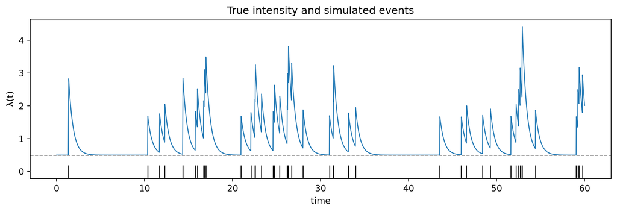

The first 60 time units. Each event (tick at the bottom) makes the intensity jump by alpha*beta, and it then decays back towards mu (dashed line). Events arrive in bursts.

```python
grid = np.linspace(0, 60, 3000)
window = times[times <= 60]
fig, ax = plt.subplots(figsize=(10, 3.5))
ax.plot(grid, intensity(grid, window, **truth), lw=1)
ax.axhline(truth["mu"], ls="--", c="grey", lw=1)
ax.plot(window, np.zeros_like(window), "|", ms=14, c="k")
ax.set(xlabel="time", ylabel="λ(t)", title="True intensity and simulated events")
plt.tight_layout()
```

# 3. The mathematics of fitting

## 3.1 The log-likelihood

For any point process on $[0, T]$:

$$\ell(\theta) = \sum_{i=1}^n \log\lambda(t_i) - \int_0^T \lambda(t)\,dt.$$

Notebook 01 (§3.1) derives this in detail. The first term rewards a high intensity where events happened. The integral (the **compensator**) is the expected number of events, and it penalises a high intensity everywhere.

## 3.2 The first term in $O(n)$

Define

$$A_i = \sum_{j<i} e^{-\beta (t_i - t_j)}, \qquad \lambda(t_i) = \mu + \alpha\beta A_i.$$

Computed directly, $A_i$ needs every earlier event, which makes $O(n^2)$ work in total. Split the lag $t_i - t_j = (t_i - t_{i-1}) + (t_{i-1} - t_j)$ to get a **recursion**:

$$A_i = e^{-\beta (t_i - t_{i-1})}\Big(\underbrace{1}_{j = i-1} + \underbrace{A_{i-1}}_{j < i-1}\Big),
\qquad A_1 = 0.$$

Each step is $O(1)$, so all the $A_i$ cost $O(n)$. This is the same Markov property the simulator uses.

## 3.3 The compensator

Integrate each term:

$$\int_0^T \lambda(t)\,dt = \mu T + \sum_{j=1}^n \alpha \int_{t_j}^{T} \beta e^{-\beta(t-t_j)}dt
= \mu T + \alpha \sum_{j=1}^n \big(1 - e^{-\beta (T - t_j)}\big).$$

An event near $T$ has had little time to trigger children, so it contributes less than $\alpha$.

Putting §3.2 and §3.3 together:

$$\boxed{\;\ell(\mu,\alpha,\beta) = \sum_{i=1}^n \log\big(\mu + \alpha\beta A_i\big) - \mu T
- \alpha\sum_{j=1}^n\big(1 - e^{-\beta(T - t_j)}\big)\;}$$

## 3.4 The exact gradient

Optimisers converge faster and more reliably with the true gradient than with finite differences. Write $\lambda_i = \mu + \alpha\beta A_i$ and $D_j = e^{-\beta(T - t_j)}$.

$$\frac{\partial\ell}{\partial\mu} = \sum_i \frac{1}{\lambda_i} - T,
\qquad
\frac{\partial\ell}{\partial\alpha} = \sum_i \frac{\beta A_i}{\lambda_i} - \sum_j (1 - D_j),$$
$$\frac{\partial\ell}{\partial\beta} = \sum_i \frac{\alpha (A_i + \beta B_i)}{\lambda_i}
- \alpha\sum_j (T - t_j) D_j,
\qquad
B_i = \frac{\partial A_i}{\partial\beta} = -\sum_{j<i}(t_i - t_j)\,e^{-\beta(t_i - t_j)}.$$

$B_i$ also has an $O(n)$ recursion. With $\Delta_i = t_i - t_{i-1}$, use the same lag split:

$$B_i = e^{-\beta\Delta_i}\big(B_{i-1} - \Delta_i (1 + A_{i-1})\big).$$

We optimise over $\phi = \log\theta$, so the gradient is converted with the chain rule: $\partial\ell/\partial\phi_k = \theta_k\,\partial\ell/\partial\theta_k$.

## 3.5 Standard errors

These work as in notebook 01: $\widehat{\text{Cov}}(\hat\phi) = [\nabla^2(-\ell)(\hat\phi)]^{-1}$ (the inverse observed information), then the delta method $\text{SE}(\hat\theta) = \hat\theta\cdot\text{SE}(\hat\phi)$.

## 3.6 Checking the fit: the time-rescaling theorem

Fitting always returns *some* parameters. To check that the model is actually right, use the **time-rescaling theorem**. If $\lambda$ is the true intensity, transform each event time by the compensator,

$$\tau_i = \Lambda(t_i) = \int_0^{t_i}\lambda(s)\,ds.$$

The transformed times $\tau_i$ then form a Poisson process with rate 1. In other words, the gaps $\tau_i - \tau_{i-1}$ are independent $\text{Exp}(1)$ draws. If the fitted model is wrong, the gaps won’t look exponential, and a QQ plot or a Kolmogorov–Smirnov test will show it.

$\Lambda(t_i)$ also has an $O(n)$ formula. Before $t_i$ there are $i-1$ events, each contributing $\alpha(1 - e^{-\beta(t_i - t_j)})$:

$$\Lambda(t_i) = \mu t_i + \alpha\big((i-1) - A_i\big).$$

These gaps are the “Ogata-style residuals” in the research plan.

# 4. The fitting code, line by line

```python
def _recursion(times, beta, with_derivative=False):
    n = len(times)
    A = np.zeros(n)
    B = np.zeros(n)
    gaps = np.diff(times)
    decay = np.exp(-beta * gaps)
    for i in range(1, n):
        A[i] = decay[i - 1] * (1.0 + A[i - 1])
        if with_derivative:
            B[i] = decay[i - 1] * (B[i - 1] - gaps[i - 1] * (1.0 + A[i - 1]))
    return (A, B) if with_derivative else A
```

**1**

$A_1 = 0$ and $B_1 = 0$: the first event has no predecessors. (Python counts from 0, so this is index 0.)

**2**

$\Delta_i = t_i - t_{i-1}$ for every $i$.

**3**

$e^{-\beta\Delta_i}$, computed for all $i$ at once.

**4**

The recursion of §3.2: $A_i = e^{-\beta\Delta_i}(1 + A_{i-1})$.

**5**

The recursion of §3.4: $B_i = e^{-\beta\Delta_i}(B_{i-1} - \Delta_i(1 + A_{i-1}))$.

```python
def neg_log_likelihood_and_grad(theta, times, T):
    mu, alpha, beta = np.exp(theta)
    A, B = _recursion(times, beta, with_derivative=True)
    lam = mu + alpha * beta * A
    tail = np.exp(-beta * (T - times))
    ll = np.sum(np.log(lam)) - mu * T - alpha * np.sum(1.0 - tail)

    d_mu = np.sum(1.0 / lam) - T
    d_alpha = np.sum(beta * A / lam) - np.sum(1.0 - tail)
    d_beta = np.sum(alpha * (A + beta * B) / lam) \
             - alpha * np.sum((T - times) * tail)
    grad_log = np.array([mu * d_mu, alpha * d_alpha, beta * d_beta])
    return -ll, -grad_log
```

**1**

The optimiser works on $\log\theta$, which keeps all three parameters positive.

**2**

$A_i$ and $B_i$ for every event, in one $O(n)$ pass.

**3**

$\lambda(t_i) = \mu + \alpha\beta A_i$ at every event.

**4**

$D_j = e^{-\beta(T - t_j)}$: the share of each event’s triggering that would fall after $T$.

**5**

The boxed log-likelihood of §3.3.

**6**

The three partial derivatives of §3.4.

**7**

Chain rule to the log scale: multiply each by its parameter.

**8**

Return the negative value and gradient, because `minimize` minimises.

```python
def fit_hawkes_temporal(times, T, start=None):
    if start is None:
        start = (0.5 * len(times) / T, 0.5, 1.0)

    def f(theta):
        return neg_log_likelihood(theta, times, T)

    def f_and_grad(theta):
        return neg_log_likelihood_and_grad(theta, times, T)

    res = minimize(f_and_grad, np.log(start), jac=True, method="BFGS")
    est = np.exp(res.x)
    cov_log = np.linalg.inv(_numerical_hessian(f, res.x))
    se = est * np.sqrt(np.diag(cov_log))
    ...
```

**1**

Starting values. The observed rate $n/T$ estimates $\mu/(1-\alpha)$, so assuming $\alpha = 0.5$ suggests $\mu \approx 0.5\,n/T$.

**2**

Value only. Used for the Hessian.

**3**

BFGS on $-\ell$. `jac=True` tells SciPy that our function returns the value and the exact gradient together.

**4**

Back to the original scale.

**5**

Inverse of the Hessian of $-\ell$ at the optimum = covariance of $\log\hat\theta$ (§3.5).

**6**

Delta method to get standard errors on the original scale.

```python
def compensator_at_events(times, mu, alpha, beta):
    A = _recursion(times, beta)
    return mu * times + alpha * (np.arange(len(times)) - A)
```

**1**

Reuse the $A_i$ recursion.

**2**

$\Lambda(t_i) = \mu t_i + \alpha((i-1) - A_i)$ from §3.6. `np.arange` gives $0, 1, 2, \dots$, which is the number of earlier events in Python’s 0-based counting.

# 5. Fitting the simulated data

```python
fit = fit_hawkes_temporal(times, T)
print(fit.summary(truth))
```

```
 param   estimate    std err     true
    mu     0.5075     0.0256   0.5000
 alpha     0.6189     0.0214   0.6000
  beta     1.9049     0.1204   2.0000
log-likelihood = -1149.77, converged = True
```

## Is the Hawkes model needed? A test against Poisson

The Poisson model is the special case $\alpha = 0$, with MLE $\hat\mu = n/T$ and log-likelihood $n\log(n/T) - n$. The **likelihood-ratio statistic** $2(\ell_{\text{Hawkes}} - \ell_{\text{Poisson}})$ measures how much better the Hawkes model fits.

```python
n = len(times)
ll_pois = n * np.log(n / T) - n
lr = 2 * (fit.log_likelihood - ll_pois)
aic = {"Poisson": 2 * 1 - 2 * ll_pois, "Hawkes": 2 * 3 - 2 * fit.log_likelihood}
print(f"LR statistic = {lr:.1f}")
print(f"AIC: Poisson {aic['Poisson']:.1f}, Hawkes {aic['Hawkes']:.1f} (lower is better)")
```

```
LR statistic = 1501.6
AIC: Poisson 3803.1, Hawkes 2305.5 (lower is better)
```

$\alpha = 0$ lies on the edge of the parameter space, so the usual $\chi^2$ reference distribution is only approximate here. That doesn’t matter: a statistic this large is decisive evidence of self-excitation.

## Goodness of fit with rescaled residuals

```
KS test vs Exp(1): Hawkes p = 0.781, Poisson p = 8.3e-106
```

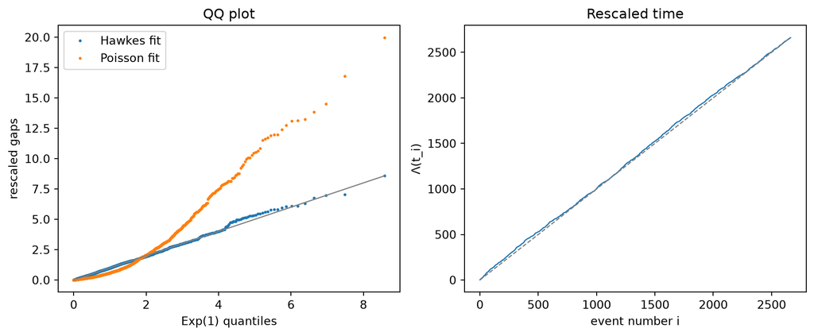

Left: QQ plot of the rescaled gaps against Exp(1). Under the fitted Hawkes model they lie on the diagonal; under a Poisson fit they bend away, because the Poisson model can’t explain the bursts. Right: rescaled time against event number. It should be a straight line of slope 1.

```python
tau_h = compensator_at_events(times, **fit.estimate)
gaps_h = np.diff(tau_h, prepend=0.0)
gaps_p = np.diff(times * n / T, prepend=0.0)  # Poisson compensator is (n/T) t

probs = (np.arange(1, n + 1) - 0.5) / n
theo = -np.log(1 - probs)
fig, axes = plt.subplots(1, 2, figsize=(10, 4.2))
axes[0].plot(theo, np.sort(gaps_h), ".", ms=3, label="Hawkes fit")
axes[0].plot(theo, np.sort(gaps_p), ".", ms=3, label="Poisson fit")
axes[0].plot([0, theo.max()], [0, theo.max()], c="grey", lw=1)
axes[0].set(xlabel="Exp(1) quantiles", ylabel="rescaled gaps", title="QQ plot")
axes[0].legend()
axes[1].plot(np.arange(1, n + 1), tau_h, lw=1)
axes[1].plot([0, n], [0, n], c="grey", ls="--", lw=1)
axes[1].set(xlabel="event number i", ylabel="Λ(t_i)", title="Rescaled time")
plt.tight_layout()

print(f"KS test vs Exp(1): Hawkes p = {kstest(gaps_h, 'expon').pvalue:.3f}, "
      f"Poisson p = {kstest(gaps_p, 'expon').pvalue:.2g}")
```

A large p-value for the Hawkes fit means no evidence against it. The Poisson fit is rejected outright.

## Repeated simulations: bias, standard errors, coverage

```python
rows = []
for seed in range(1, 101):
    ts = simulate_hawkes_thinning(**truth, T=T, seed=seed)
    f = fit_hawkes_temporal(ts, T)
    for p, true in truth.items():
        est, se = f.estimate[p], f.std_error[p]
        rows.append({"param": p, "true": true, "est": est, "se": se,
                     "covered": abs(est - true) <= 1.96 * se})
mc = pd.DataFrame(rows)
mc.groupby("param", sort=False).agg(
    true=("true", "first"),
    mean_estimate=("est", "mean"),
    sd_of_estimates=("est", "std"),
    mean_reported_se=("se", "mean"),
    ci95_coverage=("covered", "mean"),
).round(4)
```

| param | true | mean_estimate | sd_of_estimates | mean_reported_se | ci95_coverage |
| --- | --- | --- | --- | --- | --- |
| mu | 0.5 | 0.5019 | 0.0274 | 0.0248 | 0.90 |
| alpha | 0.6 | 0.5963 | 0.0195 | 0.0219 | 0.98 |
| beta | 2.0 | 2.0020 | 0.1235 | 0.1293 | 0.96 |

Over 100 repeats, the mean estimate should be close to the truth, the reported standard error should be close to the actual spread of the estimates, and coverage should be close to 0.95. With 100 repeats, anything from about 0.90 to 0.99 is consistent with 0.95.

# 6. Where this goes next

- **Regime shifts.** Let $(\mu, \alpha, \beta)$ switch at an unknown time $\tau$. The likelihood-ratio scan $\max_\tau\,[\ell(\hat\theta_{[0,\tau]}) + \ell(\hat\theta_{(\tau,T]}) - \ell(\hat\theta_{[0,T]})]$ is the classical baseline the neural detector must beat. The $O(n)$ likelihood makes the scan cheap.
- **Residuals as features.** The rescaled gaps $\Lambda(t_i) - \Lambda(t_{i-1})$ are about $\text{Exp}(1)$ under “no change”. Departures from that are what a detector should pick up.
- **Order books.** Buy and sell market orders form a 2-dimensional Hawkes process with cross-excitation $\alpha_{\text{buy}\to\text{sell}}$, etc. It’s the same thinning and the same recursion, run per pair of event types.
- **Space.** Adding a spatial kernel gives notebook 01’s model. The recursion no longer applies directly, because the spatial weights differ for every pair.